# Impactful_VisualizationCH

Valentin Henriot

01/02/2020

## Unemployment comparison between Switzerland, France, Germany and Italy

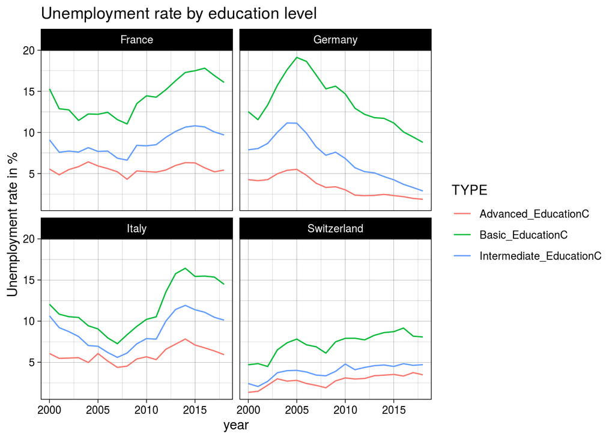

## Conclusion of the comparison

As we can see from the graph, *Switzerland* has had a relatively stable unemployment rate since the early 2000s. An increase of about **2.2% in 18 years for those with a high or intermediate level of education** and an increase of about **3.8% for those with a low level of education**. Only *Germany* is doing better than *Switzerland* in terms of unemployment at the end of 2018 for those with a high or intermediate level of education. Nevertheless, the gap remains small, **1.6% for the advanced education category** and **1.9% for the intermediate level**. *Switzerland* is doing better than *Germany* in terms of employability in the low education category, with a **0.7% gap** in favour of *Switzerland*.

In contrast, *France and Italy* are the worst performers, with unemployment rates for all education categories combined far higher than *Germany and Switzerland*. For example, the unemployment rate for the low and intermediate education categories is **twice as high** in *France* as in *Switzerland* in 2018. *Italy* shows similar results to *France*.

Finally, it is interesting to note that *Germany* has seen its **unemployment rate fall since 2005**, *Switzerland* remains **stable**, while *France and Italy* have seen their **unemployment rates rise since 2006**, although there has been a **slight improvement over the last 5 years**.